# Project 2: Data Mining, Classification, Prediction

SDS322E

# Mining, Classification, Prediction

## Name and EID here Chengmin Xu, cx2546

### Introduction

Introduction: Graduation is approaching, one of the most important things come to my mind is job. Getting a good job and earning good salary are dreams for everyone. But, what factors actually affect wage? Does education really matter? What about IQ and other factors?What would predictions look like based on the current data? These questions rouse my interest in exploring the relationship between wage and these factors by using data software(e.g. R-Studio and Python) to analyze.

The data set we use in this project is the publicly available data from a research of my major.It is a survey over 200 adults and contains 13 variables.The main variables include “wage”( monthly earnings), “hour”(average weekly hours),“IQ”(IQ score), “exper”(years of work experience),“age”(age in years), “married”(=1 if married), “black”(=1 if black), “urtban”(=1 if live in SMSA)etc.There are 24 observations for unmarried people, and 176 observations for married people;165 observations for non-black people, and 35 observations for black people.

```r
library(tidyverse)
# read your datasets in here, e.g., with read_csv()
data_wage <- read_csv("new.csv")
```

### Cluster Analysis

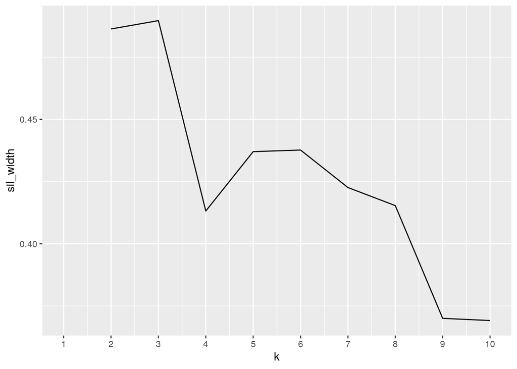

```r
library(cluster)
# clustering code here choose all variables
sil_width <- vector()
for (i in 2:10) {
    pam_fit <- pam(data_wage, k = i)
    sil_width[i] <- pam_fit$silinfo$avg.width
}
ggplot() + geom_line(aes(x = 1:10, y = sil_width)) + scale_x_continuous(name = "k",
    breaks = 1:10)
```

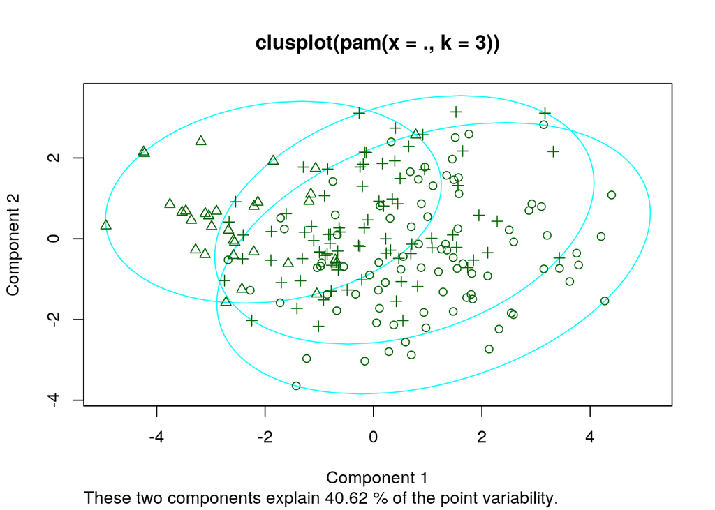

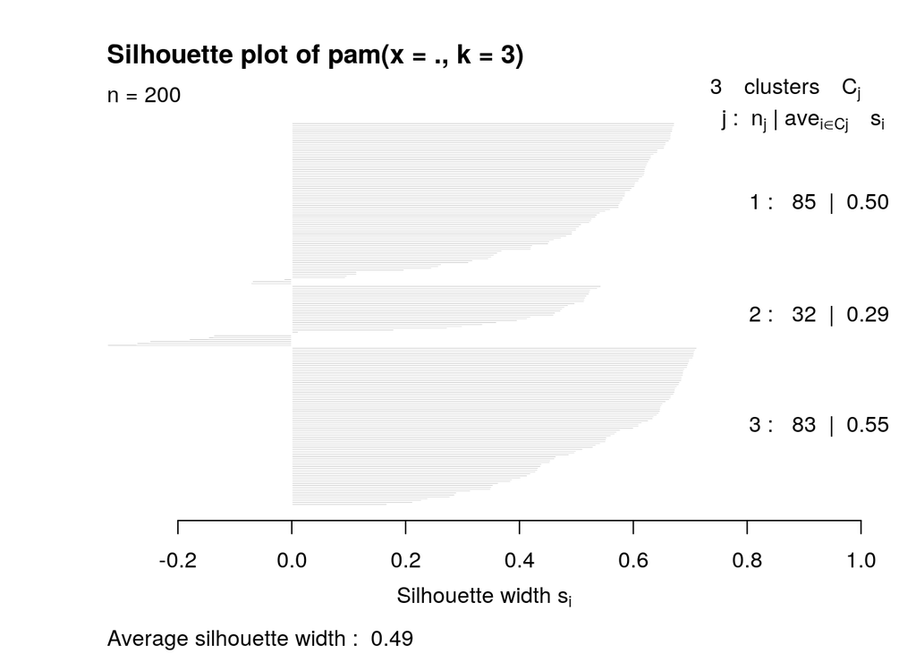

```r
wage_pam <- data_wage %>% pam(k = 3)
plot(wage_pam)
```

```r
data_wage %>% slice(wage_pam$id.med)
```

```
## # A tibble: 3 x 13
##   identity  wage hours    IQ   KWW  educ exper tenure   age married black urban
##      <dbl> <dbl> <dbl> <dbl> <dbl> <dbl> <dbl>  <dbl> <dbl>   <dbl> <dbl> <dbl>
## 1       84   754    40   104    37    13     9      5    32       1     0     1
## 2       72  1682    45   126    40    16    10     11    31       1     0     1
## 3      106  1110    52   106    42    12    11      6    33       1     0     0
## # … with 1 more variable: lwage <dbl>
```

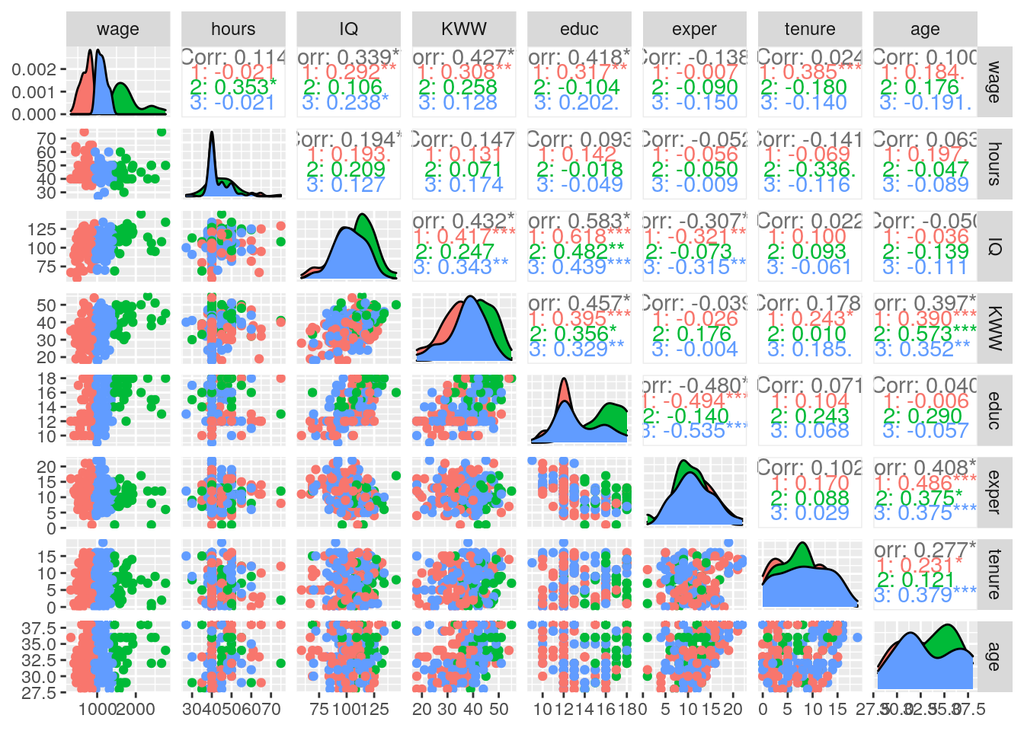

```r
library(GGally)
data_wage %>% mutate(cluster = as.factor(wage_pam$clustering)) %>%
    ggpairs(columns = 2:9, aes(color = cluster))
```

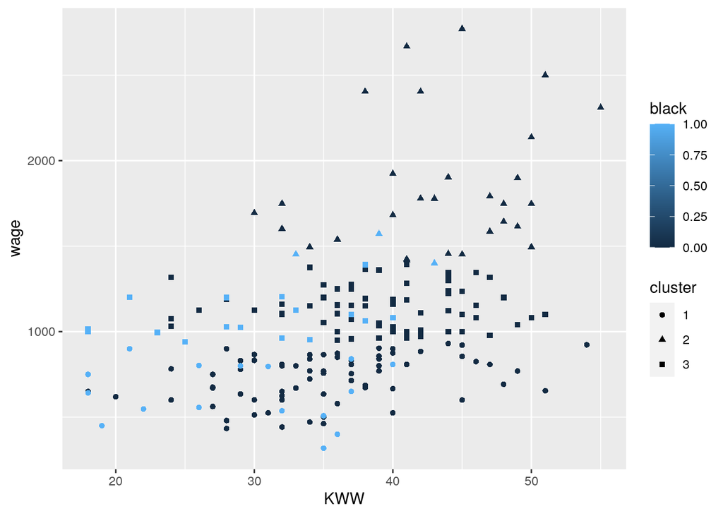

```r
# Scatter gragh
wage_pam <- data_wage %>% pam(k = 3)
pamclust <- data_wage %>% mutate(cluster = as.factor(wage_pam$clustering))
pamclust %>% ggplot(aes(KWW, wage, shape = cluster, color = black)) +
    geom_point()
```

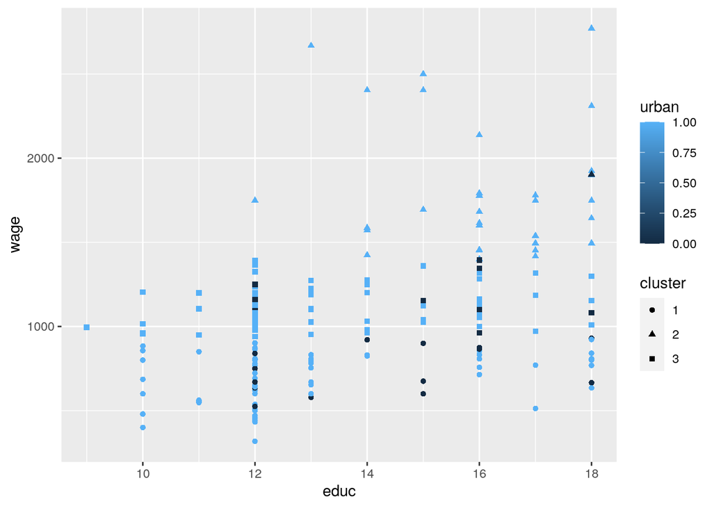

```r
pamclust <- data_wage %>% mutate(cluster = as.factor(wage_pam$clustering))
pamclust %>% ggplot(aes(educ, wage, shape = cluster, color = urban)) +
    geom_point()
```

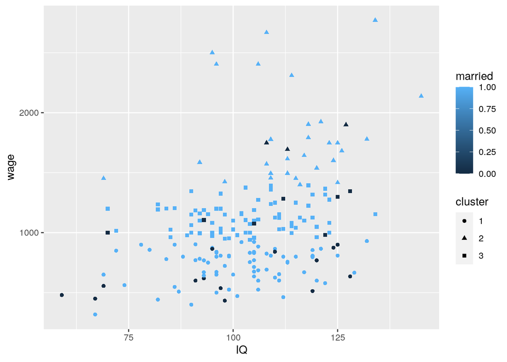

```r
pamclust <- data_wage %>% mutate(cluster = as.factor(wage_pam$clustering))
pamclust %>% ggplot(aes(IQ, wage, shape = cluster, color = married)) +
    geom_point()
```

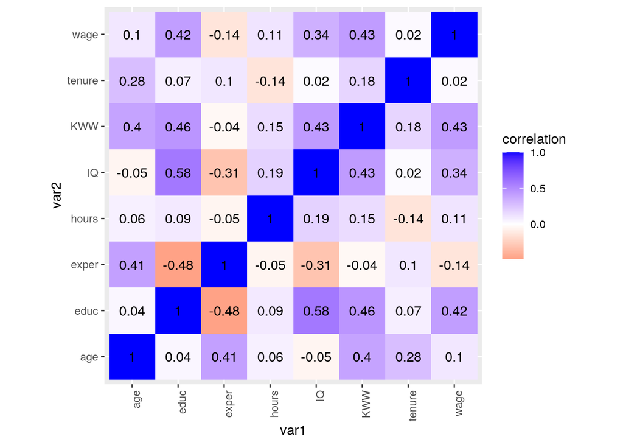

```r
# Correlation for all numeric variables except 'identity'
data_wage2 <- data_wage %>% select(-1, -10, -11, -12, -13)
tidycor <- data_wage2 %>% cor(use = "pair") %>% as.data.frame %>%
    rownames_to_column("var1") %>% pivot_longer(-1, names_to = "var2",
    values_to = "correlation")
tidycor %>% ggplot(aes(var1, var2, fill = correlation)) + geom_tile() +
    scale_fill_gradient2(low = "red", mid = "white", high = "blue") +
    geom_text(aes(label = round(correlation, 2)), color = "black") +
    theme(axis.text.x = element_text(angle = 90, hjust = 1)) +
    coord_fixed()
```

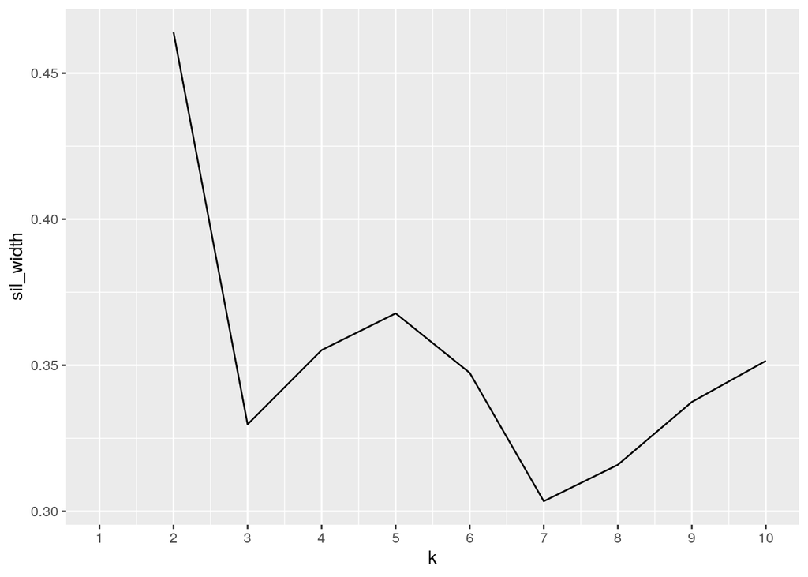

```r
# choose three numeric variables
data_wage3 <- data_wage %>% select(3, 6, 9)
sil_width <- vector()
for (i in 2:10) {
    pam_fit <- pam(data_wage3, k = i)
    sil_width[i] <- pam_fit$silinfo$avg.width
}
ggplot() + geom_line(aes(x = 1:10, y = sil_width)) + scale_x_continuous(name = "k",
    breaks = 1:10)
```

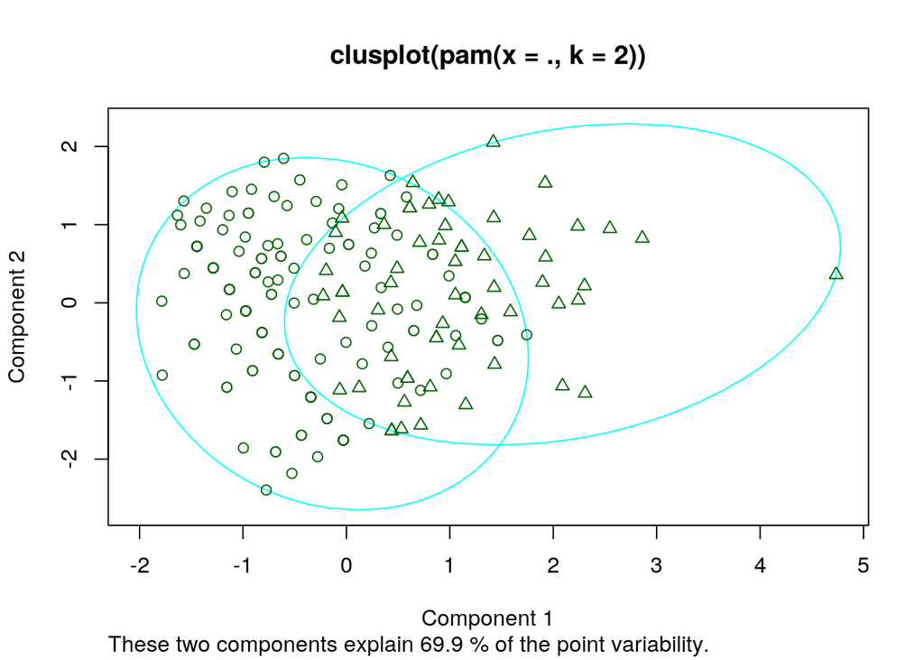

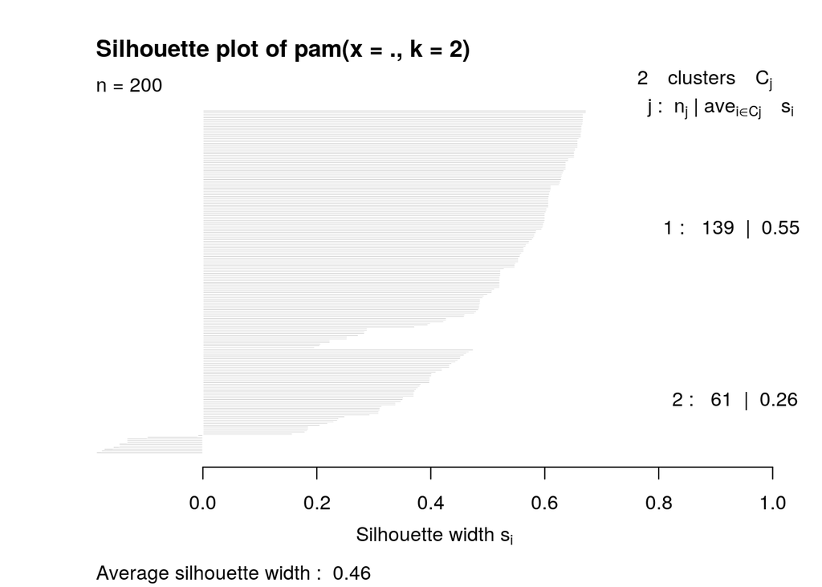

```r
wage_pam_3 <- data_wage3 %>% pam(k = 2)
plot(wage_pam_3)
```

```r
data_wage3 %>% slice(wage_pam_3$id.med)
```

```
## # A tibble: 2 x 3
##   hours  educ   age
##   <dbl> <dbl> <dbl>
## 1    40    13    32
## 2    50    14    35
```

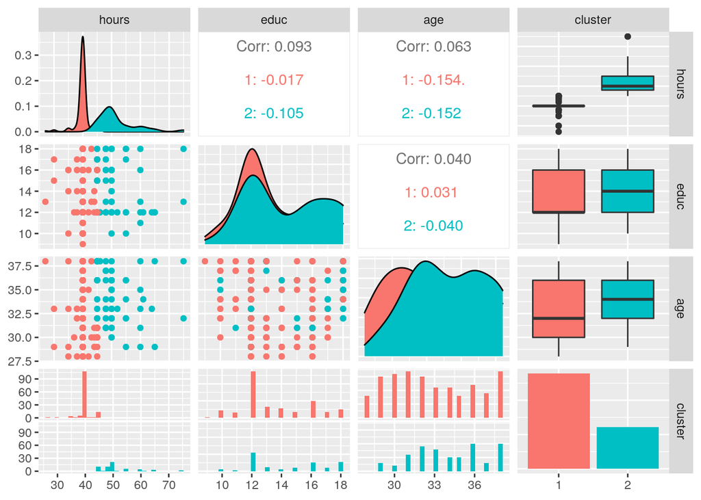

```r
library(GGally)
data_wage3 %>% mutate(cluster = as.factor(wage_pam_3$clustering)) %>%
    ggpairs(columns = c("hours", "educ", "age", "cluster"), aes(color = cluster))
```

Discussion of clustering here First, I perform PAM clustering on all my variables,picking number of clusters (which is 3) based on largest average silhouette width;However, the average silhouette width is 0.49 which means that the structure is weak and could be artificial.Then I visualize the correlation between every two variables within our model by using ggpair() and correlation table-except binary variables,and we see education and IQ has the strongest positive correlation(0.58) compared with all other combinations here. Then we take a look at KWW-wage,educ-wage,and IQ-wage to by using pam()function to see their positive relation straightforward combing with the binary variables(urban, married, black). Last, we run three numeric variables(hours, educ,age) to see whether there are some improvements on average silhouette width, but it is 0.46 and the structure is still weak and could be artificial.Also virtualize it by ggpair as before. According to the sign of the coefficient we see they are all positively correlated with each other althogh the effect magnitede is small ( close to 0).

### Dimensionality Reduction with PCA

```r
# PCA code here
data_wage2 <- data_wage %>% select(-1, -10, -11, -12, -13)
pca_data_wage2 <- princomp(data_wage2, cor = T)
names(pca_data_wage2)
```

```
## [1] "sdev"     "loadings" "center"   "scale"    "n.obs"    "scores"   "call"
```

```r
summary(pca_data_wage2, loadings = T)
```

```
## Importance of components:
##                           Comp.1    Comp.2    Comp.3     Comp.4     Comp.5
## Standard deviation     1.6013428 1.3094566 1.0468479 0.88335529 0.78829069
## Proportion of Variance 0.3205374 0.2143346 0.1369863 0.09753957 0.07767528
## Cumulative Proportion  0.3205374 0.5348719 0.6718582 0.76939781 0.84707308
##                            Comp.6     Comp.7     Comp.8
## Standard deviation     0.73672508 0.62957019 0.53319120
## Proportion of Variance 0.06784548 0.04954483 0.03553661
## Cumulative Proportion  0.91491857 0.96446339 1.00000000
##
## Loadings:
##        Comp.1 Comp.2 Comp.3 Comp.4 Comp.5 Comp.6 Comp.7 Comp.8
## wage    0.411                0.566  0.683         0.118  0.136
## hours   0.170         0.768 -0.533  0.290
## IQ      0.483 -0.116        -0.141 -0.309  0.675  0.183  0.384
## KWW     0.451  0.334         0.101 -0.234        -0.771 -0.136
## educ    0.523 -0.112 -0.176        -0.187 -0.239  0.430 -0.636
## exper  -0.282  0.521  0.234  0.213         0.538  0.160 -0.481
## tenure         0.402 -0.550 -0.565  0.436  0.137
## age            0.650  0.118        -0.267 -0.411  0.382  0.413
```

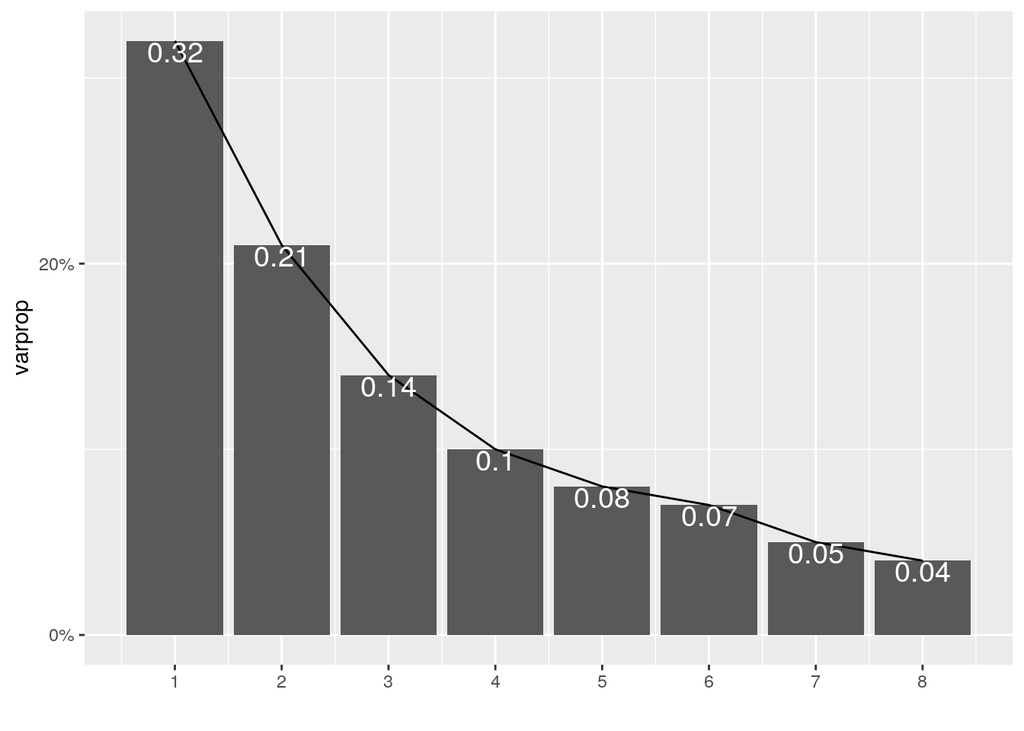

```r
eigval <- pca_data_wage2$sdev^2
varprop = round(eigval/sum(eigval), 2)

ggplot() + geom_bar(aes(y = varprop, x = 1:8), stat = "identity") +
    xlab("") + geom_path(aes(y = varprop, x = 1:8)) + geom_text(aes(x = 1:8,
    y = varprop, label = round(varprop, 2)), vjust = 1, col = "white",
    size = 5) + scale_y_continuous(breaks = seq(0, 0.6, 0.2),
    labels = scales::percent) + scale_x_continuous(breaks = 1:10)
```

```r
round(cumsum(eigval)/sum(eigval), 2)
```

```
## Comp.1 Comp.2 Comp.3 Comp.4 Comp.5 Comp.6 Comp.7 Comp.8
##   0.32   0.53   0.67   0.77   0.85   0.91   0.96   1.00
```

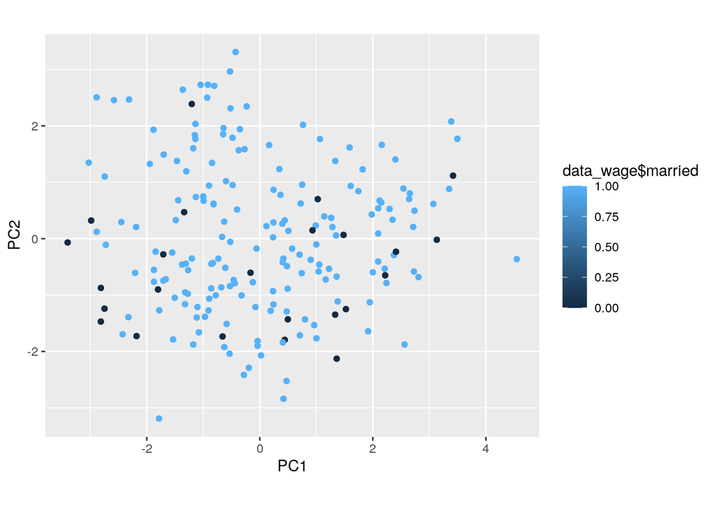

```r
data_wage2 %>% mutate(PC1 = pca_data_wage2$scores[, 1], PC2 = pca_data_wage2$scores[,
    2]) %>% ggplot(aes(PC1, PC2, color = data_wage$married)) +
    geom_point() + coord_fixed()
```

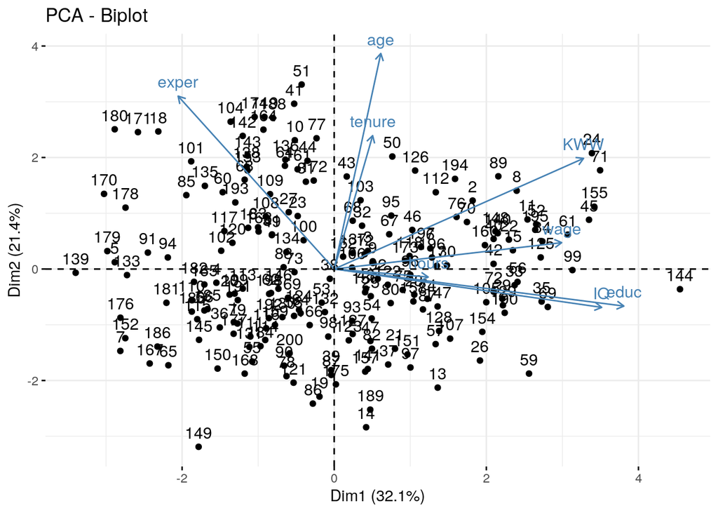

```r
library(factoextra)
fviz_pca_biplot(pca_data_wage2)
```

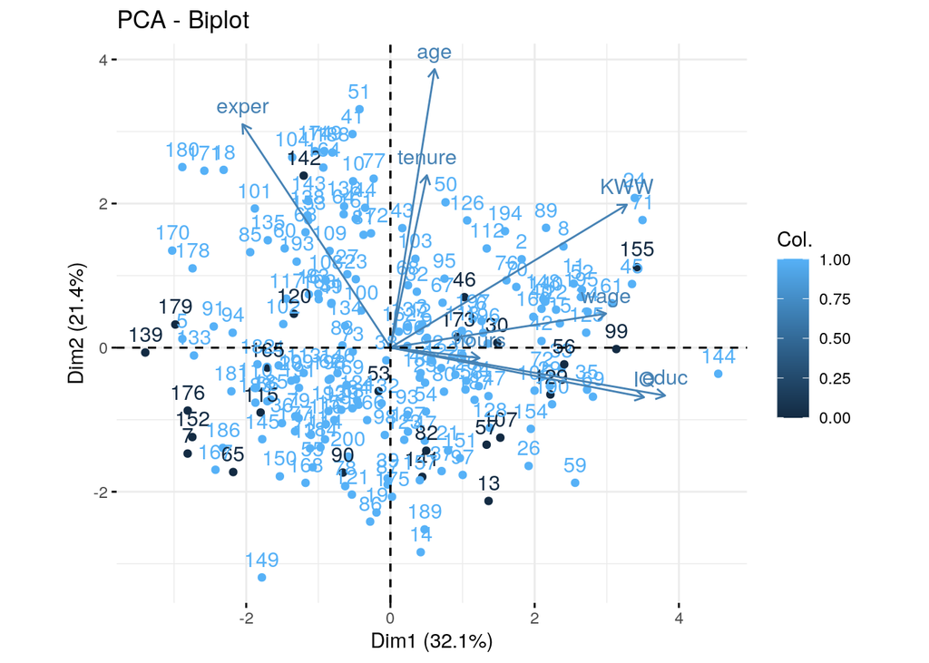

```r
fviz_pca_biplot(pca_data_wage2, col.ind = data_wage$married,
    ) + coord_fixed()
```

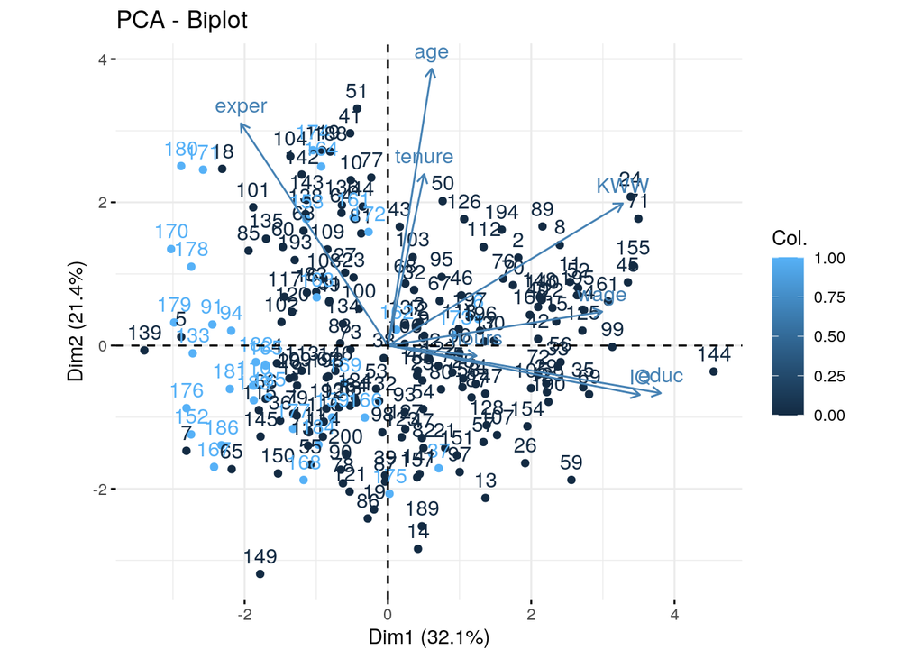

```r
fviz_pca_biplot(pca_data_wage2, col.ind = data_wage$black, ) +
    coord_fixed()
```

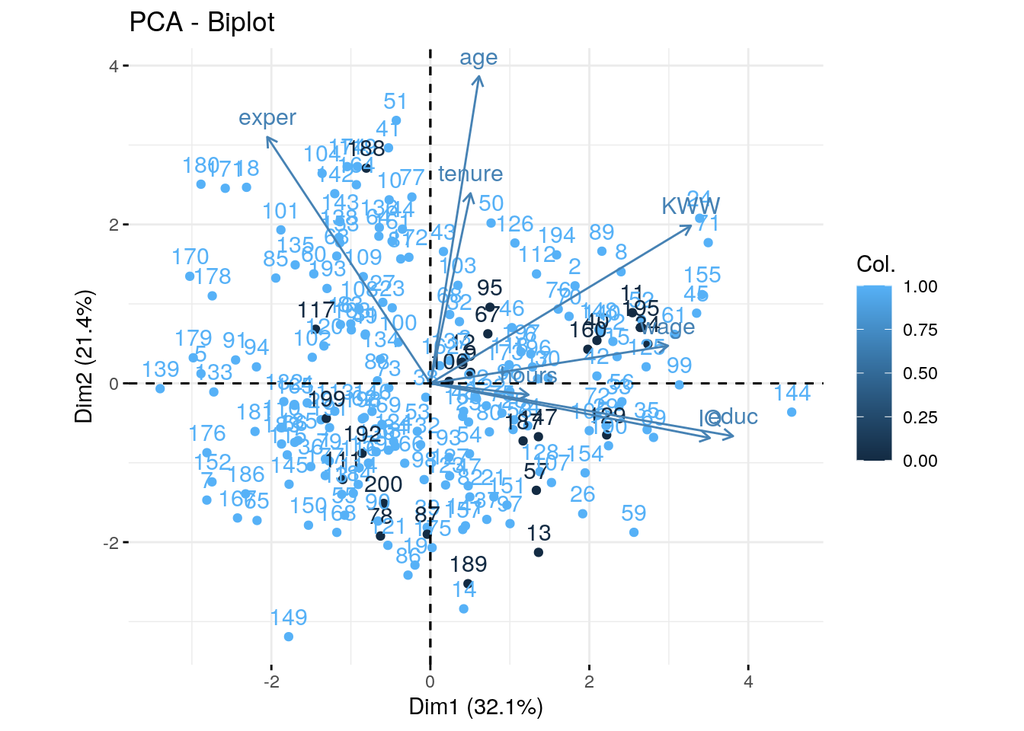

```r
fviz_pca_biplot(pca_data_wage2, col.ind = data_wage$urban, ) +
    coord_fixed()
```

Discussions of PCA here. For this part, we only focus on the data set which excludes meaningless variable(identity,etc.)and all binary variables, so there are 8 variables are used to approximate PCs.In addition, we need PCs to get 80% of the total variance and 6 PCs to get 90% of the total variance. We see for PC1,only “exper” coefficient is negative, which indicates that larger PC1,smaller “exper”but larger “wage”(and “hours”,“IQ”,“KWW”,“educ”); For PC2, only“educ”and“IQ” have negative coefficient, which indicates that the larger PC2 is,the smaller “IQ” and “educ” are but larger“KWW”(and “exper”,“tenure”,“age”) ; For PC3,the only variables having negative coefficients are “educ”and “tenure”,which indicates that the larger PC3, the smaller“educ”and “tenure” are,but larger “hours”,“exper”,“age” are; For PC4,the variables which have positive coefficients are “wage”,“KWW”and “exper”, it means that the larger PC4 is , the larger“wage”,“KWW”and “exper” are, but smaller“hours”,“IQ” and “tenure” are;For PC5,the variables which have positive coefficients are “wage”,“hour”,“tenure”, it mean the larger PC5 is, the larger “wage”,“hour”,“tenure”,but lower “IQ”(and “KWW”,etc.) are; For PC6,the only variables having negative coefficients are “educ” and “age”, which means that the larger PC6 is, the smaller “educ” and “age” are, but larger “IQ”(“educ”and “tenure”);For PC7, only“KWW” has negative coefficient,which indicates that the larger PC7 is, the smaller“KWW” is but larger “wage”(and “IQ”,etc.)are; For PC8,“KWW”,“educ” and “exper” have negative coefficients, it means the larger PC8 is,the smaller“KWW” (and “educ” etc.)are but larger“wage”(and “hour”,etc.) are.

### Linear Classifier

```r
# linear classifier code here logistic regression
class_dat <- data_wage %>% select(married, wage:age)
glimpse(class_dat)
```

```
## Rows: 200
## Columns: 9
## $ married <dbl> 1, 1, 1, 1, 1, 1, 0, 1, 1, 1, 1, 1, 0, 1, 1, 1, 1, 1, 1, 1, 1…
## $ wage    <dbl> 769, 808, 825, 650, 562, 1400, 600, 1081, 1154, 1000, 930, 92…
## $ hours   <dbl> 40, 50, 40, 40, 40, 40, 40, 40, 45, 40, 43, 38, 45, 38, 40, 5…
## $ IQ      <dbl> 93, 119, 108, 96, 74, 116, 91, 114, 111, 95, 132, 102, 125, 1…
## $ KWW     <dbl> 35, 41, 46, 32, 27, 43, 24, 50, 37, 44, 44, 45, 40, 24, 47, 3…
## $ educ    <dbl> 12, 18, 14, 12, 11, 16, 10, 18, 15, 12, 18, 14, 15, 16, 16, 1…
## $ exper   <dbl> 11, 11, 11, 13, 14, 14, 13, 8, 13, 16, 8, 9, 4, 7, 9, 17, 6, …
## $ tenure  <dbl> 2, 16, 9, 7, 5, 2, 0, 14, 1, 16, 13, 11, 3, 2, 9, 2, 9, 10, 7…
## $ age     <dbl> 31, 37, 33, 32, 34, 35, 30, 38, 36, 36, 38, 33, 30, 28, 34, 3…
```

```r
fit <- glm(married ~ ., data = class_dat, family = "binomial")
probs <- predict(fit, type = "response")
probs
```

```
##         1         2         3         4         5         6         7         8
## 0.9175851 0.7551924 0.9368302 0.8776826 0.8763312 0.9527933 0.8685062 0.9101954
##         9        10        11        12        13        14        15        16
## 0.9199521 0.9583845 0.8322721 0.9314084 0.8540173 0.7161613 0.9586203 0.9610987
##        17        18        19        20        21        22        23        24
## 0.8993440 0.9557489 0.7159019 0.8624648 0.9215517 0.9629229 0.9116431 0.9810749
##        25        26        27        28        29        30        31        32
## 0.8507447 0.7508385 0.9608192 0.8483275 0.8952429 0.6554031 0.9646929 0.9549507
##        33        34        35        36        37        38        39        40
## 0.9726140 0.5992729 0.9151352 0.7229890 0.9378631 0.9008163 0.8445674 0.9077894
##        41        42        43        44        45        46        47        48
## 0.9735160 0.9299250 0.9761454 0.9459558 0.9319388 0.8926473 0.6902082 0.8676223
##        49        50        51        52        53        54        55        56
## 0.9509435 0.9353539 0.9745876 0.8981944 0.9359183 0.8034154 0.8849351 0.8165592
##        57        58        59        60        61        62        63        64
## 0.8439084 0.9297024 0.8841754 0.9039878 0.9444687 0.9015386 0.8945021 0.9807989
##        65        66        67        68        69        70        71        72
## 0.6403340 0.8430482 0.9375443 0.9406886 0.9401890 0.9255176 0.9853138 0.9006010
##        73        74        75        76        77        78        79        80
## 0.9755157 0.9070118 0.8442959 0.9318238 0.9555636 0.7226273 0.9318376 0.8872006
##        81        82        83        84        85        86        87        88
## 0.9868339 0.8801116 0.9455134 0.8965758 0.9533622 0.7849611 0.8601679 0.9032300
##        89        90        91        92        93        94        95        96
## 0.9894395 0.7594384 0.7996005 0.9018091 0.8046223 0.9091245 0.9017142 0.9159992
##        97        98        99       100
## 0.7148993 0.8234333 0.8072898 0.9186902
##  [ reached getOption("max.print") -- omitted 100 entries ]
```

```r
class_diag(probs, truth = class_dat$married, positive = 1)
```

```
##          acc sens spec  ppv     f1  ba    auc
## Metrics 0.88    1    0 0.88 0.9362 0.5 0.7076
```

```r
y_hat <- ifelse(probs > 0.5, "1", "0")
y_hat <- factor(y_hat, levels = c("0", "1"))
table(truth = class_dat$married, predictions = y_hat)
```

```
##      predictions
## truth   0   1
##     0   0  24
##     1   0 176
```

```r
# cross-validation of linear classifier here K-fold CV
k = 10
data <- sample_frac(class_dat)
folds <- rep(1:k, length.out = nrow(data))

diags <- NULL

i = 1

for (i in 1:k) {
    train <- data[folds != i, ]
    test <- data[folds == i, ]
    truth <- test$married

    fit <- glm(married ~ ., data = train, family = "binomial")
    probs <- predict(fit, newdata = test, type = "response")
    diags <- rbind(diags, class_diag(probs, truth, positive = 1))
}
summarize_all(diags, mean)
```

```
##     acc    sens spec     ppv      f1  ba     auc
## 1 0.875 0.99375  NaN 0.87895 0.93163 NaN 0.58853
```

### Non-Parametric Classifier

```r
library(caret)
# non-parametric classifier code here
class_dat <- data_wage %>% select(married, wage:age)
knn_fit <- knn3(married ~ ., data = class_dat)
probs_knn <- predict(knn_fit, class_dat)[, 2]
probs_knn
```

```
##   [1] 1.0 1.0 1.0 1.0 0.4 1.0 0.6 1.0 1.0 1.0 0.8 1.0 0.6 0.6 0.8 1.0 0.8 0.8
##  [19] 0.8 0.8 0.8 1.0 0.6 0.8 1.0 1.0 1.0 1.0 1.0 0.8 1.0 1.0 1.0 1.0 1.0 1.0
##  [37] 1.0 0.8 1.0 1.0 1.0 0.6 1.0 1.0 0.8 0.8 1.0 1.0 1.0 1.0 0.8 1.0 0.8 1.0
##  [55] 0.8 0.8 0.6 1.0 1.0 1.0 0.8 1.0 0.8 1.0 0.6 0.6 1.0 0.8 0.8 1.0 1.0 0.8
##  [73] 1.0 0.6 0.8 1.0 1.0 1.0 0.8 0.8 1.0 0.6 1.0 1.0 0.8 0.8 0.8 1.0 1.0 0.8
##  [91] 1.0 1.0 0.8 1.0 1.0 1.0 0.6 1.0 0.6 1.0
##  [ reached getOption("max.print") -- omitted 100 entries ]
```

```r
class_diag(probs_knn, class_dat$married, positive = 1)
```

```
##          acc   sens   spec    ppv     f1    ba    auc
## Metrics 0.88 0.9943 0.0417 0.8838 0.9358 0.518 0.8655
```

```r
y_hat_knn <- ifelse(probs_knn > 0.5, "1", "0")
y_hat_knn <- factor(y_hat_knn, levels = c("0", "1"))
table(truth = class_dat$married, predictions = y_hat_knn)
```

```
##      predictions
## truth   0   1
##     0   1  23
##     1   1 175
```

```r
# cross-validation of np classifier here
library(caret)
k = 10
data <- sample_frac(class_dat)
folds <- rep(1:k, length.out = nrow(data))

diags <- NULL

i = 1

for (i in 1:k) {
    train <- data[folds != i, ]
    test <- data[folds == i, ]
    truth <- test$married

    knn_fit <- knn3(married ~ ., data = train)
    probs_knn <- predict(knn_fit, newdata = test)[, 2]

    diags <- rbind(diags, class_diag(probs_knn, truth, positive = 1))
}
summarize_all(diags, mean)
```

```
##    acc sens spec  ppv     f1  ba     auc
## 1 0.87 0.99  NaN 0.88 0.9291 NaN 0.68053
```

### Regression/Numeric Prediction

```r
# regression model code here

fit_linear <- lm(IQ ~ educ + KWW + exper, data = data_wage)
props_linear <- predict(fit_linear)
props_linear
```

```
##         1         2         3         4         5         6         7         8
##  98.35892 117.60173 108.78632  96.36593  91.04754 111.98815  87.27624 122.59778
##         9        10        11        12        13        14        15        16
## 106.87914 100.73385 119.92236 108.99570 111.16562 105.80947 115.40997  91.76242
##        17        18        19        20        21        22        23        24
## 110.06443  93.42247 103.49945  97.25774 105.42847 115.97413  97.82190 114.12655
##        25        26        27        28        29        30        31        32
## 109.07620 109.04906 101.71146 116.70992 115.49578 115.90923  98.62259 105.24624
##        33        34        35        36        37        38        39        40
## 103.46793 118.13875 116.26932  96.87050 106.97556 101.12015 110.95093 119.83124
##        41        42        43        44        45        46        47        48
## 100.87926 117.84356 100.73385 103.02203 121.28722 107.21209 113.02973 110.29565
##        49        50        51        52        53        54        55        56
##  97.16662 105.48807  99.21390 120.15888  96.36593 109.84975  98.35892 122.15188
##        57        58        59        60        61        62        63        64
## 112.28864  97.58538 119.90052  95.50127 118.28946  97.58538  95.61953 101.74392
##        65        66        67        68        69        70        71        72
##  91.99801  96.69357 110.77401  98.38607 121.70597 114.39990 123.51673 111.96100
##        73        74        75        76        77        78        79        80
## 103.14560 113.86288 111.93386 113.86818 100.85211 104.05831  96.03829 103.00019
##        81        82        83        84        85        86        87        88
## 100.08387 105.06838  92.86361 102.66724  93.63715 101.18412 102.54898  99.04135
##        89        90        91        92        93        94        95        96
## 113.44943  95.41983  89.14036 115.82342 110.95093  98.26781 101.21657 110.32810
##        97        98        99       100
## 112.68025 110.62329 120.57764 101.78074
##  [ reached getOption("max.print") -- omitted 100 entries ]
```

```r
fit_linear_sum <- summary(fit_linear)
mean(fit_linear_sum$residuals^2)
```

```
## [1] 142.2229
```

```r
# cross-validation of regression model here
k = 10
data <- sample_frac(data_wage)
folds <- rep(1:k, length.out = nrow(data))

MSE <- NULL

i = 1

for (i in 1:k) {
    train <- data[folds != i, ]
    test <- data[folds == i, ]

    fit_linear <- lm(IQ ~ educ + KWW + exper, data = train)
    probs_linear <- predict(fit_linear, newdata = test, type = "response")
    MSE <- rbind(MSE, mean(summary(fit_linear)$residuals^2))
}

mean(MSE)
```

```
## [1] 141.9672
```

Discussion There is no signal of overfitting because there is a very little decrease between mean of MSE not in CV(142.2) and mean of MSE in CV (141.9)

### Python

```r
library(reticulate)
use_python("/usr/bin/python3", required = F)
wage_median <- median(data_wage$wage)
wage_mean <- mean(data_wage$wage)
```

```python
# python code here
next1="The median wage of our data set is"
next2="The average wage of our data set is"
print(next1, r.wage_median)
```

```
## The median wage of our data set is 1000.0
```

```r
use_python("/usr/bin/python3", required = F)
cat(c(py$next2, wage_mean))
```

```
## The average wage of our data set is 1059.59
```

Discussion First, I use R to define the meaning/function for mean and median of the most important variable in this model–wage.Then I use python chunk to define the two sentences to describe the conclusion, as well as print out the full conclusion for the median of wage in words by combining the sentence defined in python and the function/result defining in R using r.. Next, I use R chunk to connect the sentence defined in Python chunk with another function/result we defined in the previous R chunk(mean of wage)by using py$, and finally got the full conclusion sentence for mean wage.

### Concluding Remarks

Include concluding remarks here, if any According to this study, we see wage is positively related to age, eduction, hours of work,IQ, knowledge about the world, and the years in current position. Hence, to get a good job and higher salary we need to work hard both in universities and in companies. MOst obviously, IQ is highly positively related to education. Additionally, the model(married~.)performs not so good both in linear classifier and non-parametric classifier,and we should not need to keep this model anymore, and the model (IQ ~educ+KWW+exper) used on this study shows no overfitting signal, hence we may could use it to explore more further more.